# Risk Factor Analysis

## Outcome Variable

**Outcome Variable:** y_rate_haz

## Predictor Variables

**Intervention Variable:** fhtcm

**Adjustment Set:**

unadjusted

## Stratifying Variables

The analysis was stratified on these variable(s):

- agecat
- studyid
- country

## Data Summary

| agecat | studyid | country | fhtcm | n_cell | n |
| --- | --- | --- | --- | --- | --- |
| 0-3 months | ki1000304b-SAS-CompFeed | INDIA | >=167 cm | 326 | 716 |
| 0-3 months | ki1000304b-SAS-CompFeed | INDIA | <162 cm | 184 | 716 |
| 0-3 months | ki1000304b-SAS-CompFeed | INDIA | [162-167) cm | 206 | 716 |
| 0-3 months | ki1101329-Keneba | GAMBIA | >=167 cm | 631 | 965 |
| 0-3 months | ki1101329-Keneba | GAMBIA | <162 cm | 75 | 965 |
| 0-3 months | ki1101329-Keneba | GAMBIA | [162-167) cm | 259 | 965 |
| 0-3 months | ki1119695-PROBIT | BELARUS | >=167 cm | 10773 | 11500 |
| 0-3 months | ki1119695-PROBIT | BELARUS | <162 cm | 151 | 11500 |
| 0-3 months | ki1119695-PROBIT | BELARUS | [162-167) cm | 576 | 11500 |
| 0-3 months | ki1135781-COHORTS | GUATEMALA | >=167 cm | 25 | 180 |
| 0-3 months | ki1135781-COHORTS | GUATEMALA | <162 cm | 106 | 180 |
| 0-3 months | ki1135781-COHORTS | GUATEMALA | [162-167) cm | 49 | 180 |
| 3-6 months | ki1000304b-SAS-CompFeed | INDIA | >=167 cm | 308 | 682 |
| 3-6 months | ki1000304b-SAS-CompFeed | INDIA | <162 cm | 175 | 682 |
| 3-6 months | ki1000304b-SAS-CompFeed | INDIA | [162-167) cm | 199 | 682 |
| 3-6 months | ki1101329-Keneba | GAMBIA | >=167 cm | 673 | 1037 |
| 3-6 months | ki1101329-Keneba | GAMBIA | <162 cm | 74 | 1037 |
| 3-6 months | ki1101329-Keneba | GAMBIA | [162-167) cm | 290 | 1037 |
| 3-6 months | ki1119695-PROBIT | BELARUS | >=167 cm | 9473 | 10104 |
| 3-6 months | ki1119695-PROBIT | BELARUS | <162 cm | 129 | 10104 |
| 3-6 months | ki1119695-PROBIT | BELARUS | [162-167) cm | 502 | 10104 |
| 3-6 months | ki1135781-COHORTS | GUATEMALA | >=167 cm | 37 | 261 |
| 3-6 months | ki1135781-COHORTS | GUATEMALA | <162 cm | 148 | 261 |
| 3-6 months | ki1135781-COHORTS | GUATEMALA | [162-167) cm | 76 | 261 |
| 6-12 months | ki1000304b-SAS-CompFeed | INDIA | >=167 cm | 313 | 679 |
| 6-12 months | ki1000304b-SAS-CompFeed | INDIA | <162 cm | 164 | 679 |
| 6-12 months | ki1000304b-SAS-CompFeed | INDIA | [162-167) cm | 202 | 679 |
| 6-12 months | ki1000304b-SAS-FoodSuppl | INDIA | >=167 cm | 89 | 328 |
| 6-12 months | ki1000304b-SAS-FoodSuppl | INDIA | <162 cm | 132 | 328 |
| 6-12 months | ki1000304b-SAS-FoodSuppl | INDIA | [162-167) cm | 107 | 328 |
| 6-12 months | ki1101329-Keneba | GAMBIA | >=167 cm | 635 | 1005 |
| 6-12 months | ki1101329-Keneba | GAMBIA | <162 cm | 78 | 1005 |
| 6-12 months | ki1101329-Keneba | GAMBIA | [162-167) cm | 292 | 1005 |
| 6-12 months | ki1119695-PROBIT | BELARUS | >=167 cm | 9248 | 9870 |
| 6-12 months | ki1119695-PROBIT | BELARUS | <162 cm | 124 | 9870 |
| 6-12 months | ki1119695-PROBIT | BELARUS | [162-167) cm | 498 | 9870 |
| 6-12 months | ki1135781-COHORTS | GUATEMALA | >=167 cm | 45 | 329 |
| 6-12 months | ki1135781-COHORTS | GUATEMALA | <162 cm | 192 | 329 |
| 6-12 months | ki1135781-COHORTS | GUATEMALA | [162-167) cm | 92 | 329 |
| 12-24 months | ki1101329-Keneba | GAMBIA | >=167 cm | 583 | 931 |
| 12-24 months | ki1101329-Keneba | GAMBIA | <162 cm | 73 | 931 |
| 12-24 months | ki1101329-Keneba | GAMBIA | [162-167) cm | 275 | 931 |
| 12-24 months | ki1119695-PROBIT | BELARUS | >=167 cm | 2169 | 2320 |
| 12-24 months | ki1119695-PROBIT | BELARUS | <162 cm | 38 | 2320 |
| 12-24 months | ki1119695-PROBIT | BELARUS | [162-167) cm | 113 | 2320 |
| 12-24 months | ki1135781-COHORTS | GUATEMALA | >=167 cm | 58 | 421 |
| 12-24 months | ki1135781-COHORTS | GUATEMALA | <162 cm | 244 | 421 |
| 12-24 months | ki1135781-COHORTS | GUATEMALA | [162-167) cm | 119 | 421 |

The following strata were considered:

- agecat: 0-3 months, studyid: ki1000304b-SAS-CompFeed, country: INDIA
- agecat: 0-3 months, studyid: ki1101329-Keneba, country: GAMBIA
- agecat: 0-3 months, studyid: ki1119695-PROBIT, country: BELARUS
- agecat: 0-3 months, studyid: ki1135781-COHORTS, country: GUATEMALA
- agecat: 12-24 months, studyid: ki1101329-Keneba, country: GAMBIA
- agecat: 12-24 months, studyid: ki1119695-PROBIT, country: BELARUS
- agecat: 12-24 months, studyid: ki1135781-COHORTS, country: GUATEMALA
- agecat: 3-6 months, studyid: ki1000304b-SAS-CompFeed, country: INDIA
- agecat: 3-6 months, studyid: ki1101329-Keneba, country: GAMBIA
- agecat: 3-6 months, studyid: ki1119695-PROBIT, country: BELARUS
- agecat: 3-6 months, studyid: ki1135781-COHORTS, country: GUATEMALA
- agecat: 6-12 months, studyid: ki1000304b-SAS-CompFeed, country: INDIA
- agecat: 6-12 months, studyid: ki1000304b-SAS-FoodSuppl, country: INDIA
- agecat: 6-12 months, studyid: ki1101329-Keneba, country: GAMBIA
- agecat: 6-12 months, studyid: ki1119695-PROBIT, country: BELARUS
- agecat: 6-12 months, studyid: ki1135781-COHORTS, country: GUATEMALA

## Methods Detail

We’re interested in the causal parameters $E[Y_a]$ for all values of $a \in \mathcal{A}$. These parameters represent the mean outcome if, possibly contrary to fact, we intervened to set all units to have $A=a$. Under the randomization and positivity assumptions, these are identified by the statistical parameters $\psi_a=E_W[E_{Y|A,W}(Y|A=a,W)]$. In addition, we’re interested in the mean of $Y$, $E[Y]$ under no intervention (the observed mean). We will estimate these parameters by using SuperLearner to fit the relevant likelihood factors – $E_{Y|A,W}(Y|A=a,W)$ and $p(A=a|W)$, and then updating our likelihood fit using a joint TMLE.

For unadjusted analyses ($W=\{\}$), initial likelihoods were estimated using Lrnr_glm to estimate the simple $E(Y|A)$ and Lrnr_mean to estimate $p(A)$. For adjusted analyses, a small library containing Lrnr_glmnet, Lrnr_xgboost, and Lrnr_mean was used.

Having estimated these parameters, we will then use the delta method to estimate relative risks and attributable risks relative to a prespecified baseline level of $A$.

# Results Detail

## Results Plots

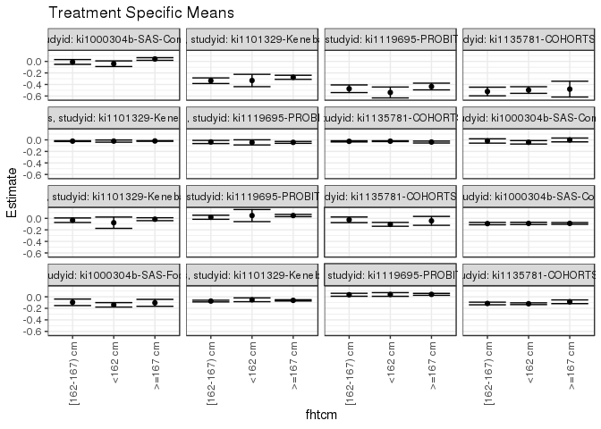

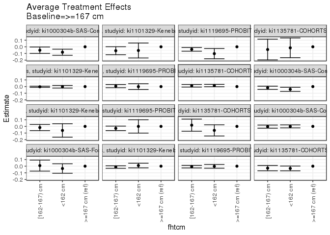

## Results Table

### Parameter: TSM

| agecat | studyid | country | intervention_level | baseline_level | estimate | ci_lower | ci_upper |
| --- | --- | --- | --- | --- | --- | --- | --- |
| 0-3 months | ki1000304b-SAS-CompFeed | INDIA | >=167 cm | NA | 0.0417142 | 0.0186427 | 0.0647858 |
| 0-3 months | ki1000304b-SAS-CompFeed | INDIA | <162 cm | NA | -0.0400383 | -0.0890252 | 0.0089486 |
| 0-3 months | ki1000304b-SAS-CompFeed | INDIA | [162-167) cm | NA | -0.0096510 | -0.0511551 | 0.0318532 |
| 0-3 months | ki1101329-Keneba | GAMBIA | >=167 cm | NA | -0.2756029 | -0.3112181 | -0.2399878 |
| 0-3 months | ki1101329-Keneba | GAMBIA | <162 cm | NA | -0.3311234 | -0.4381988 | -0.2240480 |
| 0-3 months | ki1101329-Keneba | GAMBIA | [162-167) cm | NA | -0.3346711 | -0.3832427 | -0.2860994 |
| 0-3 months | ki1119695-PROBIT | BELARUS | >=167 cm | NA | -0.4355808 | -0.4941207 | -0.3770409 |
| 0-3 months | ki1119695-PROBIT | BELARUS | <162 cm | NA | -0.5387062 | -0.6331912 | -0.4442211 |
| 0-3 months | ki1119695-PROBIT | BELARUS | [162-167) cm | NA | -0.4739508 | -0.5403643 | -0.4075374 |
| 0-3 months | ki1135781-COHORTS | GUATEMALA | >=167 cm | NA | -0.4807190 | -0.6177738 | -0.3436643 |
| 0-3 months | ki1135781-COHORTS | GUATEMALA | <162 cm | NA | -0.4964554 | -0.5538836 | -0.4390272 |
| 0-3 months | ki1135781-COHORTS | GUATEMALA | [162-167) cm | NA | -0.5218430 | -0.5969706 | -0.4467154 |
| 3-6 months | ki1000304b-SAS-CompFeed | INDIA | >=167 cm | NA | -0.0014411 | -0.0347557 | 0.0318735 |
| 3-6 months | ki1000304b-SAS-CompFeed | INDIA | <162 cm | NA | -0.0426204 | -0.0727132 | -0.0125275 |
| 3-6 months | ki1000304b-SAS-CompFeed | INDIA | [162-167) cm | NA | -0.0192522 | -0.0569095 | 0.0184051 |
| 3-6 months | ki1101329-Keneba | GAMBIA | >=167 cm | NA | -0.0150521 | -0.0404454 | 0.0103411 |
| 3-6 months | ki1101329-Keneba | GAMBIA | <162 cm | NA | -0.0762347 | -0.1744078 | 0.0219384 |
| 3-6 months | ki1101329-Keneba | GAMBIA | [162-167) cm | NA | -0.0326117 | -0.0716051 | 0.0063818 |
| 3-6 months | ki1119695-PROBIT | BELARUS | >=167 cm | NA | 0.0483273 | 0.0290272 | 0.0676274 |
| 3-6 months | ki1119695-PROBIT | BELARUS | <162 cm | NA | 0.0480643 | -0.0568052 | 0.1529339 |
| 3-6 months | ki1119695-PROBIT | BELARUS | [162-167) cm | NA | 0.0186631 | -0.0168469 | 0.0541730 |
| 3-6 months | ki1135781-COHORTS | GUATEMALA | >=167 cm | NA | -0.0438737 | -0.1209529 | 0.0332055 |
| 3-6 months | ki1135781-COHORTS | GUATEMALA | <162 cm | NA | -0.1039207 | -0.1374128 | -0.0704287 |
| 3-6 months | ki1135781-COHORTS | GUATEMALA | [162-167) cm | NA | -0.0255358 | -0.0740817 | 0.0230102 |
| 6-12 months | ki1000304b-SAS-CompFeed | INDIA | >=167 cm | NA | -0.0879068 | -0.1029226 | -0.0728911 |
| 6-12 months | ki1000304b-SAS-CompFeed | INDIA | <162 cm | NA | -0.0883524 | -0.1078987 | -0.0688061 |
| 6-12 months | ki1000304b-SAS-CompFeed | INDIA | [162-167) cm | NA | -0.0912116 | -0.1117555 | -0.0706678 |
| 6-12 months | ki1000304b-SAS-FoodSuppl | INDIA | >=167 cm | NA | -0.1044974 | -0.1648120 | -0.0441827 |
| 6-12 months | ki1000304b-SAS-FoodSuppl | INDIA | <162 cm | NA | -0.1394491 | -0.1777799 | -0.1011183 |
| 6-12 months | ki1000304b-SAS-FoodSuppl | INDIA | [162-167) cm | NA | -0.0958043 | -0.1524600 | -0.0391487 |
| 6-12 months | ki1101329-Keneba | GAMBIA | >=167 cm | NA | -0.0619460 | -0.0730704 | -0.0508215 |
| 6-12 months | ki1101329-Keneba | GAMBIA | <162 cm | NA | -0.0522863 | -0.0853903 | -0.0191824 |
| 6-12 months | ki1101329-Keneba | GAMBIA | [162-167) cm | NA | -0.0743436 | -0.0895768 | -0.0591105 |
| 6-12 months | ki1119695-PROBIT | BELARUS | >=167 cm | NA | 0.0420751 | 0.0253049 | 0.0588453 |
| 6-12 months | ki1119695-PROBIT | BELARUS | <162 cm | NA | 0.0400100 | 0.0082805 | 0.0717395 |
| 6-12 months | ki1119695-PROBIT | BELARUS | [162-167) cm | NA | 0.0350399 | 0.0095682 | 0.0605116 |
| 6-12 months | ki1135781-COHORTS | GUATEMALA | >=167 cm | NA | -0.0864592 | -0.1188067 | -0.0541117 |
| 6-12 months | ki1135781-COHORTS | GUATEMALA | <162 cm | NA | -0.1203646 | -0.1360456 | -0.1046836 |
| 6-12 months | ki1135781-COHORTS | GUATEMALA | [162-167) cm | NA | -0.1160064 | -0.1389710 | -0.0930417 |
| 12-24 months | ki1101329-Keneba | GAMBIA | >=167 cm | NA | -0.0190298 | -0.0246009 | -0.0134586 |
| 12-24 months | ki1101329-Keneba | GAMBIA | <162 cm | NA | -0.0214617 | -0.0402720 | -0.0026514 |
| 12-24 months | ki1101329-Keneba | GAMBIA | [162-167) cm | NA | -0.0219443 | -0.0292341 | -0.0146545 |
| 12-24 months | ki1119695-PROBIT | BELARUS | >=167 cm | NA | -0.0432264 | -0.0598584 | -0.0265945 |
| 12-24 months | ki1119695-PROBIT | BELARUS | <162 cm | NA | -0.0437834 | -0.0881962 | 0.0006294 |
| 12-24 months | ki1119695-PROBIT | BELARUS | [162-167) cm | NA | -0.0365610 | -0.0637751 | -0.0093468 |
| 12-24 months | ki1135781-COHORTS | GUATEMALA | >=167 cm | NA | -0.0379111 | -0.0545409 | -0.0212814 |
| 12-24 months | ki1135781-COHORTS | GUATEMALA | <162 cm | NA | -0.0227814 | -0.0297169 | -0.0158459 |
| 12-24 months | ki1135781-COHORTS | GUATEMALA | [162-167) cm | NA | -0.0256518 | -0.0356398 | -0.0156637 |

### Parameter: E(Y)

| agecat | studyid | country | intervention_level | baseline_level | estimate | ci_lower | ci_upper |
| --- | --- | --- | --- | --- | --- | --- | --- |
| 0-3 months | ki1000304b-SAS-CompFeed | INDIA | NA | NA | 0.0059269 | -0.0151835 | 0.0270374 |
| 0-3 months | ki1101329-Keneba | GAMBIA | NA | NA | -0.2957715 | -0.3237824 | -0.2677606 |
| 0-3 months | ki1119695-PROBIT | BELARUS | NA | NA | -0.4388567 | -0.4976461 | -0.3800673 |
| 0-3 months | ki1135781-COHORTS | GUATEMALA | NA | NA | -0.5011808 | -0.5450937 | -0.4572680 |
| 3-6 months | ki1000304b-SAS-CompFeed | INDIA | NA | NA | -0.0172047 | -0.0462110 | 0.0118016 |
| 3-6 months | ki1101329-Keneba | GAMBIA | NA | NA | -0.0243287 | -0.0453184 | -0.0033389 |
| 3-6 months | ki1119695-PROBIT | BELARUS | NA | NA | 0.0468501 | 0.0275580 | 0.0661423 |
| 3-6 months | ki1135781-COHORTS | GUATEMALA | NA | NA | -0.0725836 | -0.0990295 | -0.0461377 |
| 6-12 months | ki1000304b-SAS-CompFeed | INDIA | NA | NA | -0.0889976 | -0.1017879 | -0.0762074 |
| 6-12 months | ki1000304b-SAS-FoodSuppl | INDIA | NA | NA | -0.1157275 | -0.1449160 | -0.0865389 |
| 6-12 months | ki1101329-Keneba | GAMBIA | NA | NA | -0.0647984 | -0.0735026 | -0.0560942 |
| 6-12 months | ki1119695-PROBIT | BELARUS | NA | NA | 0.0416942 | 0.0249522 | 0.0584361 |
| 6-12 months | ki1135781-COHORTS | GUATEMALA | NA | NA | -0.1145084 | -0.1265939 | -0.1024228 |
| 12-24 months | ki1101329-Keneba | GAMBIA | NA | NA | -0.0200813 | -0.0244392 | -0.0157235 |
| 12-24 months | ki1119695-PROBIT | BELARUS | NA | NA | -0.0429109 | -0.0593629 | -0.0264588 |
| 12-24 months | ki1135781-COHORTS | GUATEMALA | NA | NA | -0.0256771 | -0.0311186 | -0.0202357 |

### Parameter: ATE

| agecat | studyid | country | intervention_level | baseline_level | estimate | ci_lower | ci_upper |
| --- | --- | --- | --- | --- | --- | --- | --- |
| 0-3 months | ki1000304b-SAS-CompFeed | INDIA | >=167 cm | >=167 cm | 0.0000000 | 0.0000000 | 0.0000000 |
| 0-3 months | ki1000304b-SAS-CompFeed | INDIA | <162 cm | >=167 cm | -0.0817525 | -0.1276557 | -0.0358492 |
| 0-3 months | ki1000304b-SAS-CompFeed | INDIA | [162-167) cm | >=167 cm | -0.0513652 | -0.0995949 | -0.0031355 |
| 0-3 months | ki1101329-Keneba | GAMBIA | >=167 cm | >=167 cm | 0.0000000 | 0.0000000 | 0.0000000 |
| 0-3 months | ki1101329-Keneba | GAMBIA | <162 cm | >=167 cm | -0.0555205 | -0.1683636 | 0.0573226 |
| 0-3 months | ki1101329-Keneba | GAMBIA | [162-167) cm | >=167 cm | -0.0590682 | -0.1192981 | 0.0011618 |
| 0-3 months | ki1119695-PROBIT | BELARUS | >=167 cm | >=167 cm | 0.0000000 | 0.0000000 | 0.0000000 |
| 0-3 months | ki1119695-PROBIT | BELARUS | <162 cm | >=167 cm | -0.1031254 | -0.1805383 | -0.0257124 |
| 0-3 months | ki1119695-PROBIT | BELARUS | [162-167) cm | >=167 cm | -0.0383701 | -0.0662718 | -0.0104683 |
| 0-3 months | ki1135781-COHORTS | GUATEMALA | >=167 cm | >=167 cm | 0.0000000 | 0.0000000 | 0.0000000 |
| 0-3 months | ki1135781-COHORTS | GUATEMALA | <162 cm | >=167 cm | -0.0157363 | -0.1643364 | 0.1328638 |
| 0-3 months | ki1135781-COHORTS | GUATEMALA | [162-167) cm | >=167 cm | -0.0411239 | -0.1974190 | 0.1151711 |
| 3-6 months | ki1000304b-SAS-CompFeed | INDIA | >=167 cm | >=167 cm | 0.0000000 | 0.0000000 | 0.0000000 |
| 3-6 months | ki1000304b-SAS-CompFeed | INDIA | <162 cm | >=167 cm | -0.0411792 | -0.0720410 | -0.0103175 |
| 3-6 months | ki1000304b-SAS-CompFeed | INDIA | [162-167) cm | >=167 cm | -0.0178111 | -0.0420517 | 0.0064296 |
| 3-6 months | ki1101329-Keneba | GAMBIA | >=167 cm | >=167 cm | 0.0000000 | 0.0000000 | 0.0000000 |
| 3-6 months | ki1101329-Keneba | GAMBIA | <162 cm | >=167 cm | -0.0611826 | -0.1625866 | 0.0402215 |
| 3-6 months | ki1101329-Keneba | GAMBIA | [162-167) cm | >=167 cm | -0.0175595 | -0.0640924 | 0.0289734 |
| 3-6 months | ki1119695-PROBIT | BELARUS | >=167 cm | >=167 cm | 0.0000000 | 0.0000000 | 0.0000000 |
| 3-6 months | ki1119695-PROBIT | BELARUS | <162 cm | >=167 cm | -0.0002630 | -0.1006727 | 0.1001467 |
| 3-6 months | ki1119695-PROBIT | BELARUS | [162-167) cm | >=167 cm | -0.0296642 | -0.0637272 | 0.0043987 |
| 3-6 months | ki1135781-COHORTS | GUATEMALA | >=167 cm | >=167 cm | 0.0000000 | 0.0000000 | 0.0000000 |
| 3-6 months | ki1135781-COHORTS | GUATEMALA | <162 cm | >=167 cm | -0.0600471 | -0.1440882 | 0.0239941 |
| 3-6 months | ki1135781-COHORTS | GUATEMALA | [162-167) cm | >=167 cm | 0.0183379 | -0.0727549 | 0.1094308 |
| 6-12 months | ki1000304b-SAS-CompFeed | INDIA | >=167 cm | >=167 cm | 0.0000000 | 0.0000000 | 0.0000000 |
| 6-12 months | ki1000304b-SAS-CompFeed | INDIA | <162 cm | >=167 cm | -0.0004456 | -0.0232194 | 0.0223283 |
| 6-12 months | ki1000304b-SAS-CompFeed | INDIA | [162-167) cm | >=167 cm | -0.0033048 | -0.0264464 | 0.0198369 |
| 6-12 months | ki1000304b-SAS-FoodSuppl | INDIA | >=167 cm | >=167 cm | 0.0000000 | 0.0000000 | 0.0000000 |
| 6-12 months | ki1000304b-SAS-FoodSuppl | INDIA | <162 cm | >=167 cm | -0.0349518 | -0.1064158 | 0.0365122 |
| 6-12 months | ki1000304b-SAS-FoodSuppl | INDIA | [162-167) cm | >=167 cm | 0.0086930 | -0.0740579 | 0.0914440 |
| 6-12 months | ki1101329-Keneba | GAMBIA | >=167 cm | >=167 cm | 0.0000000 | 0.0000000 | 0.0000000 |
| 6-12 months | ki1101329-Keneba | GAMBIA | <162 cm | >=167 cm | 0.0096596 | -0.0252635 | 0.0445827 |
| 6-12 months | ki1101329-Keneba | GAMBIA | [162-167) cm | >=167 cm | -0.0123977 | -0.0312604 | 0.0064650 |
| 6-12 months | ki1119695-PROBIT | BELARUS | >=167 cm | >=167 cm | 0.0000000 | 0.0000000 | 0.0000000 |
| 6-12 months | ki1119695-PROBIT | BELARUS | <162 cm | >=167 cm | -0.0020651 | -0.0301852 | 0.0260550 |
| 6-12 months | ki1119695-PROBIT | BELARUS | [162-167) cm | >=167 cm | -0.0070352 | -0.0266967 | 0.0126263 |
| 6-12 months | ki1135781-COHORTS | GUATEMALA | >=167 cm | >=167 cm | 0.0000000 | 0.0000000 | 0.0000000 |
| 6-12 months | ki1135781-COHORTS | GUATEMALA | <162 cm | >=167 cm | -0.0339054 | -0.0698534 | 0.0020425 |
| 6-12 months | ki1135781-COHORTS | GUATEMALA | [162-167) cm | >=167 cm | -0.0295472 | -0.0692175 | 0.0101232 |
| 12-24 months | ki1101329-Keneba | GAMBIA | >=167 cm | >=167 cm | 0.0000000 | 0.0000000 | 0.0000000 |
| 12-24 months | ki1101329-Keneba | GAMBIA | <162 cm | >=167 cm | -0.0024320 | -0.0220500 | 0.0171860 |
| 12-24 months | ki1101329-Keneba | GAMBIA | [162-167) cm | >=167 cm | -0.0029145 | -0.0120894 | 0.0062604 |
| 12-24 months | ki1119695-PROBIT | BELARUS | >=167 cm | >=167 cm | 0.0000000 | 0.0000000 | 0.0000000 |
| 12-24 months | ki1119695-PROBIT | BELARUS | <162 cm | >=167 cm | -0.0005570 | -0.0433372 | 0.0422231 |
| 12-24 months | ki1119695-PROBIT | BELARUS | [162-167) cm | >=167 cm | 0.0066655 | -0.0175622 | 0.0308931 |
| 12-24 months | ki1135781-COHORTS | GUATEMALA | >=167 cm | >=167 cm | 0.0000000 | 0.0000000 | 0.0000000 |
| 12-24 months | ki1135781-COHORTS | GUATEMALA | <162 cm | >=167 cm | 0.0151297 | -0.0028883 | 0.0331477 |
| 12-24 months | ki1135781-COHORTS | GUATEMALA | [162-167) cm | >=167 cm | 0.0122594 | -0.0071393 | 0.0316580 |